# Racial Segregation in Jury Panels

# The Distribution of the Test Statistic, Under the Null Hypothesis

What if we select a random sample of 1,453 people from the population of eligible jurors? Will the distribution of their ethnicities look like the distribution of the panels above?

```python
# The TVD of a model simluation from its expected values

alameda_sample_size = 1453 #given
model_proportion = jury.column('Eligible')
simulated_distribution = sample_proportions(alameda_sample_size, model_proportion)
simulated_distribution
```

```
array([ 0.15347557,  0.18375774,  0.10805231,  0.54783207,  0.00688231])
```

```python
# The actual observed distribution (Panels) looks quite different
jury_with_simulated = jury.with_column('Simulated', simulated_distribution)
jury_with_simulated
```

| Ethnicity | Eligible | Panels | Simulated |
| --- | --- | --- | --- |
| Asian | 0.15 | 0.26 | 0.153476 |
| Black | 0.18 | 0.08 | 0.183758 |
| Latino | 0.12 | 0.08 | 0.108052 |
| White | 0.54 | 0.54 | 0.547832 |
| Other | 0.01 | 0.04 | 0.00688231 |

```python
tvd(jury_with_simulated.column('Simulated'), jury_with_simulated.column('Eligible'))
```

```
0.015065381968341337
```

Technical note. Random samples of prospective jurors would be selected without replacement. However, when the size of a sample is small relative to the size of the population, sampling without replacement resembles sampling with replacement; the proportions in the population don’t change much between draws. The population of eligible jurors in Alameda County is over a million, and compared to that, a sample size of about 1500 is quite small. We will therefore sample with replacement.

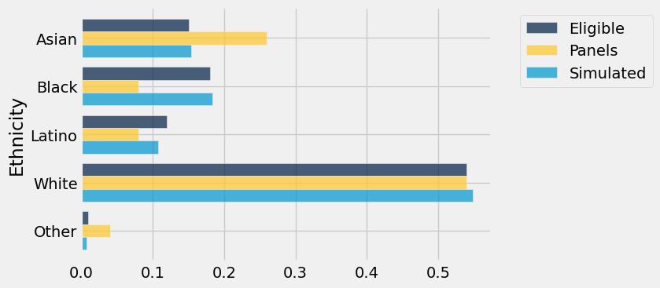

```python
jury_with_simulated.barh('Ethnicity')
```

```python
def simulated_tvd():
    simulated_distribution = sample_proportions(alameda_sample_size, model_proportion)
    return tvd(simulated_distribution, jury_with_simulated.column('Eligible'))
```

```python
simulated_tvd()
```

```
0.011383344803854081
```

```python
tvds = make_array()

num_simulations = 10_000

for i in np.arange(num_simulations):
    tvds = np.append(tvds, simulated_tvd())
```

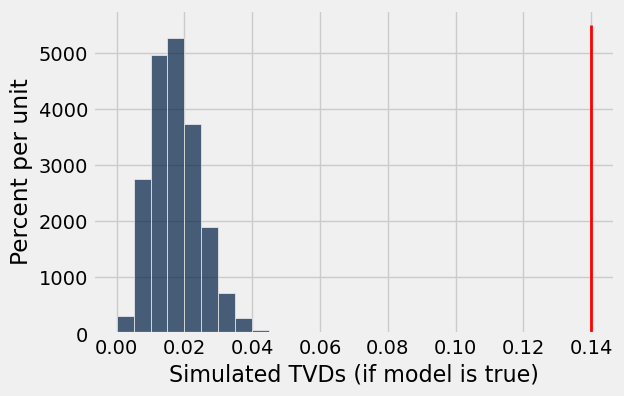

```python
title = 'Simulated TVDs (if model is true)'
bins = np.arange(0, .05, .005)

Table().with_column(title, tvds).hist(bins = bins)
plots.plot([observed_tvd, observed_tvd], [0, 55], color='red', lw=2);
#need to go from 0 to 5500 so convert 5500 to 55% so go from 0, 55
```

```python
#reject null hypothesis b/c p-value = 0 bc there are 0 values greater than 0.14
```